# Risk Factor Analysis

## Outcome Variable

**Outcome Variable:** ever_wasted

## Predictor Variables

**Intervention Variable:** exclfeed3

**Adjustment Set:**

- arm
- sex
- brthmon
- W_mage
- meducyrs
- feducyrs
- hhwealth_quart
- hfoodsec
- W_mhtcm
- W_mwtkg
- W_mbmi
- vagbrth
- W_gagebrth
- W_birthwt
- W_birthlen
- W_nrooms
- W_nchldlt5
- month
- W_parity
- impfloor
- impsan
- safeh20
- delta_W_mage
- delta_meducyrs
- delta_feducyrs
- delta_hhwealth_quart
- delta_hfoodsec
- delta_W_mhtcm
- delta_W_mwtkg
- delta_W_mbmi
- delta_vagbrth
- delta_W_gagebrth
- delta_W_birthwt
- delta_W_birthlen
- delta_W_nrooms
- delta_W_nchldlt5
- delta_month
- delta_W_parity
- delta_impfloor
- delta_impsan
- delta_safeh20

## Stratifying Variables

The analysis was stratified on these variable(s):

- agecat
- studyid
- country

## Data Summary

| agecat | studyid | country | exclfeed3 | ever_wasted | n_cell | n |
| --- | --- | --- | --- | --- | --- | --- |
| 0-24 months (no birth wast) | CMC-V-BCS-2002 | INDIA | 1 | 0 | 4 | 10 |
| 0-24 months (no birth wast) | CMC-V-BCS-2002 | INDIA | 1 | 1 | 6 | 10 |
| 0-24 months (no birth wast) | CMC-V-BCS-2002 | INDIA | 0 | 0 | 0 | 10 |
| 0-24 months (no birth wast) | CMC-V-BCS-2002 | INDIA | 0 | 1 | 0 | 10 |
| 0-24 months (no birth wast) | EE | PAKISTAN | 1 | 0 | 18 | 39 |
| 0-24 months (no birth wast) | EE | PAKISTAN | 1 | 1 | 21 | 39 |
| 0-24 months (no birth wast) | EE | PAKISTAN | 0 | 0 | 0 | 39 |
| 0-24 months (no birth wast) | EE | PAKISTAN | 0 | 1 | 0 | 39 |
| 0-24 months (no birth wast) | GMS-Nepal | NEPAL | 1 | 0 | 147 | 453 |
| 0-24 months (no birth wast) | GMS-Nepal | NEPAL | 1 | 1 | 229 | 453 |
| 0-24 months (no birth wast) | GMS-Nepal | NEPAL | 0 | 0 | 39 | 453 |
| 0-24 months (no birth wast) | GMS-Nepal | NEPAL | 0 | 1 | 38 | 453 |
| 0-24 months (no birth wast) | IRC | INDIA | 1 | 0 | 0 | 10 |
| 0-24 months (no birth wast) | IRC | INDIA | 1 | 1 | 0 | 10 |
| 0-24 months (no birth wast) | IRC | INDIA | 0 | 0 | 4 | 10 |
| 0-24 months (no birth wast) | IRC | INDIA | 0 | 1 | 6 | 10 |
| 0-24 months (no birth wast) | JiVitA-3 | BANGLADESH | 1 | 0 | 11034 | 14768 |
| 0-24 months (no birth wast) | JiVitA-3 | BANGLADESH | 1 | 1 | 2327 | 14768 |
| 0-24 months (no birth wast) | JiVitA-3 | BANGLADESH | 0 | 0 | 1167 | 14768 |
| 0-24 months (no birth wast) | JiVitA-3 | BANGLADESH | 0 | 1 | 240 | 14768 |
| 0-24 months (no birth wast) | JiVitA-4 | BANGLADESH | 1 | 0 | 109 | 164 |
| 0-24 months (no birth wast) | JiVitA-4 | BANGLADESH | 1 | 1 | 38 | 164 |
| 0-24 months (no birth wast) | JiVitA-4 | BANGLADESH | 0 | 0 | 13 | 164 |
| 0-24 months (no birth wast) | JiVitA-4 | BANGLADESH | 0 | 1 | 4 | 164 |
| 0-24 months (no birth wast) | Keneba | GAMBIA | 1 | 0 | 1100 | 2015 |
| 0-24 months (no birth wast) | Keneba | GAMBIA | 1 | 1 | 695 | 2015 |
| 0-24 months (no birth wast) | Keneba | GAMBIA | 0 | 0 | 120 | 2015 |
| 0-24 months (no birth wast) | Keneba | GAMBIA | 0 | 1 | 100 | 2015 |
| 0-24 months (no birth wast) | MAL-ED | BANGLADESH | 1 | 0 | 123 | 244 |
| 0-24 months (no birth wast) | MAL-ED | BANGLADESH | 1 | 1 | 36 | 244 |

[output cut: 162 more lines]

The following strata were considered:

- agecat: 0-24 months (no birth wast), studyid: CMC-V-BCS-2002, country: INDIA
- agecat: 0-24 months (no birth wast), studyid: EE, country: PAKISTAN
- agecat: 0-24 months (no birth wast), studyid: GMS-Nepal, country: NEPAL
- agecat: 0-24 months (no birth wast), studyid: IRC, country: INDIA
- agecat: 0-24 months (no birth wast), studyid: JiVitA-3, country: BANGLADESH
- agecat: 0-24 months (no birth wast), studyid: JiVitA-4, country: BANGLADESH
- agecat: 0-24 months (no birth wast), studyid: Keneba, country: GAMBIA
- agecat: 0-24 months (no birth wast), studyid: MAL-ED, country: BANGLADESH
- agecat: 0-24 months (no birth wast), studyid: MAL-ED, country: BRAZIL
- agecat: 0-24 months (no birth wast), studyid: MAL-ED, country: INDIA
- agecat: 0-24 months (no birth wast), studyid: MAL-ED, country: NEPAL
- agecat: 0-24 months (no birth wast), studyid: MAL-ED, country: PERU
- agecat: 0-24 months (no birth wast), studyid: MAL-ED, country: SOUTH AFRICA
- agecat: 0-24 months (no birth wast), studyid: MAL-ED, country: TANZANIA, UNITED REPUBLIC OF
- agecat: 0-24 months (no birth wast), studyid: PROVIDE, country: BANGLADESH
- agecat: 0-24 months (no birth wast), studyid: SAS-CompFeed, country: INDIA
- agecat: 0-6 months (no birth wast), studyid: CMC-V-BCS-2002, country: INDIA
- agecat: 0-6 months (no birth wast), studyid: EE, country: PAKISTAN
- agecat: 0-6 months (no birth wast), studyid: GMS-Nepal, country: NEPAL
- agecat: 0-6 months (no birth wast), studyid: IRC, country: INDIA
- agecat: 0-6 months (no birth wast), studyid: JiVitA-3, country: BANGLADESH
- agecat: 0-6 months (no birth wast), studyid: JiVitA-4, country: BANGLADESH
- agecat: 0-6 months (no birth wast), studyid: Keneba, country: GAMBIA
- agecat: 0-6 months (no birth wast), studyid: MAL-ED, country: BANGLADESH
- agecat: 0-6 months (no birth wast), studyid: MAL-ED, country: BRAZIL
- agecat: 0-6 months (no birth wast), studyid: MAL-ED, country: INDIA
- agecat: 0-6 months (no birth wast), studyid: MAL-ED, country: NEPAL
- agecat: 0-6 months (no birth wast), studyid: MAL-ED, country: PERU
- agecat: 0-6 months (no birth wast), studyid: MAL-ED, country: SOUTH AFRICA
- agecat: 0-6 months (no birth wast), studyid: MAL-ED, country: TANZANIA, UNITED REPUBLIC OF
- agecat: 0-6 months (no birth wast), studyid: PROVIDE, country: BANGLADESH
- agecat: 0-6 months (no birth wast), studyid: SAS-CompFeed, country: INDIA
- agecat: 6-24 months, studyid: CMC-V-BCS-2002, country: INDIA
- agecat: 6-24 months, studyid: EE, country: PAKISTAN
- agecat: 6-24 months, studyid: GMS-Nepal, country: NEPAL
- agecat: 6-24 months, studyid: IRC, country: INDIA
- agecat: 6-24 months, studyid: JiVitA-3, country: BANGLADESH
- agecat: 6-24 months, studyid: JiVitA-4, country: BANGLADESH
- agecat: 6-24 months, studyid: Keneba, country: GAMBIA
- agecat: 6-24 months, studyid: MAL-ED, country: BANGLADESH
- agecat: 6-24 months, studyid: MAL-ED, country: BRAZIL
- agecat: 6-24 months, studyid: MAL-ED, country: INDIA
- agecat: 6-24 months, studyid: MAL-ED, country: NEPAL
- agecat: 6-24 months, studyid: MAL-ED, country: PERU
- agecat: 6-24 months, studyid: MAL-ED, country: SOUTH AFRICA
- agecat: 6-24 months, studyid: MAL-ED, country: TANZANIA, UNITED REPUBLIC OF
- agecat: 6-24 months, studyid: PROVIDE, country: BANGLADESH
- agecat: 6-24 months, studyid: SAS-CompFeed, country: INDIA

### Dropped Strata

Some strata were dropped due to rare outcomes:

- agecat: 0-24 months (no birth wast), studyid: CMC-V-BCS-2002, country: INDIA
- agecat: 0-24 months (no birth wast), studyid: EE, country: PAKISTAN
- agecat: 0-24 months (no birth wast), studyid: IRC, country: INDIA
- agecat: 0-24 months (no birth wast), studyid: JiVitA-4, country: BANGLADESH
- agecat: 0-24 months (no birth wast), studyid: MAL-ED, country: PERU
- agecat: 0-24 months (no birth wast), studyid: MAL-ED, country: SOUTH AFRICA
- agecat: 0-6 months (no birth wast), studyid: CMC-V-BCS-2002, country: INDIA
- agecat: 0-6 months (no birth wast), studyid: EE, country: PAKISTAN
- agecat: 0-6 months (no birth wast), studyid: IRC, country: INDIA
- agecat: 0-6 months (no birth wast), studyid: JiVitA-4, country: BANGLADESH
- agecat: 0-6 months (no birth wast), studyid: MAL-ED, country: BRAZIL
- agecat: 0-6 months (no birth wast), studyid: MAL-ED, country: NEPAL
- agecat: 0-6 months (no birth wast), studyid: MAL-ED, country: PERU
- agecat: 0-6 months (no birth wast), studyid: MAL-ED, country: SOUTH AFRICA
- agecat: 0-6 months (no birth wast), studyid: MAL-ED, country: TANZANIA, UNITED REPUBLIC OF
- agecat: 6-24 months, studyid: CMC-V-BCS-2002, country: INDIA
- agecat: 6-24 months, studyid: EE, country: PAKISTAN
- agecat: 6-24 months, studyid: IRC, country: INDIA
- agecat: 6-24 months, studyid: JiVitA-4, country: BANGLADESH
- agecat: 6-24 months, studyid: MAL-ED, country: BRAZIL
- agecat: 6-24 months, studyid: MAL-ED, country: PERU
- agecat: 6-24 months, studyid: MAL-ED, country: SOUTH AFRICA
- agecat: 6-24 months, studyid: MAL-ED, country: TANZANIA, UNITED REPUBLIC OF

## Methods Detail

We’re interested in the causal parameters $E[Y_a]$ for all values of $a \in \mathcal{A}$. These parameters represent the mean outcome if, possibly contrary to fact, we intervened to set all units to have $A=a$. Under the randomization and positivity assumptions, these are identified by the statistical parameters $\psi_a=E_W[E_{Y|A,W}(Y|A=a,W)]$. In addition, we’re interested in the mean of $Y$, $E[Y]$ under no intervention (the observed mean). We will estimate these parameters by using SuperLearner to fit the relevant likelihood factors – $E_{Y|A,W}(Y|A=a,W)$ and $p(A=a|W)$, and then updating our likelihood fit using a joint TMLE.

For unadjusted analyses ($W=\{\}$), initial likelihoods were estimated using Lrnr_glm to estimate the simple $E(Y|A)$ and Lrnr_mean to estimate $p(A)$. For adjusted analyses, a small library containing Lrnr_glmnet, Lrnr_xgboost, and Lrnr_mean was used.

Having estimated these parameters, we will then use the delta method to estimate relative risks and attributable risks relative to a prespecified baseline level of $A$.

# Results Detail

## Results Plots

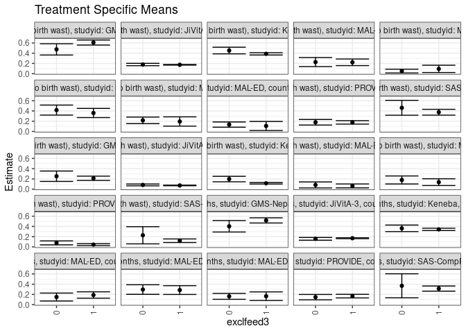

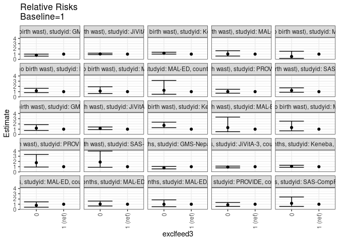

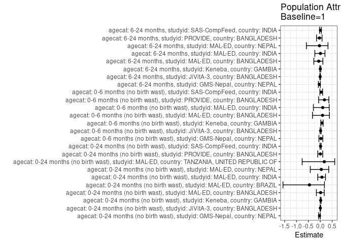

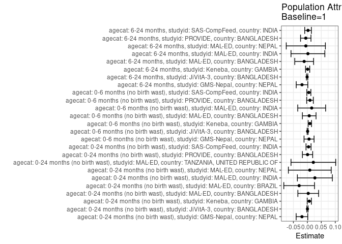

## Results Table

### Parameter: TSM

| agecat | studyid | country | intervention_level | baseline_level | estimate | ci_lower | ci_upper |
| --- | --- | --- | --- | --- | --- | --- | --- |
| 0-24 months (no birth wast) | GMS-Nepal | NEPAL | 1 | NA | 0.6086925 | 0.5595133 | 0.6578717 |
| 0-24 months (no birth wast) | GMS-Nepal | NEPAL | 0 | NA | 0.4747641 | 0.3645736 | 0.5849547 |
| 0-24 months (no birth wast) | JiVitA-3 | BANGLADESH | 1 | NA | 0.1734868 | 0.1665220 | 0.1804516 |
| 0-24 months (no birth wast) | JiVitA-3 | BANGLADESH | 0 | NA | 0.1786964 | 0.1557667 | 0.2016260 |
| 0-24 months (no birth wast) | Keneba | GAMBIA | 1 | NA | 0.3876014 | 0.3650911 | 0.4101117 |
| 0-24 months (no birth wast) | Keneba | GAMBIA | 0 | NA | 0.4522191 | 0.3875552 | 0.5168831 |
| 0-24 months (no birth wast) | MAL-ED | BANGLADESH | 1 | NA | 0.2221930 | 0.1574689 | 0.2869171 |
| 0-24 months (no birth wast) | MAL-ED | BANGLADESH | 0 | NA | 0.2269952 | 0.1384207 | 0.3155697 |
| 0-24 months (no birth wast) | MAL-ED | BRAZIL | 1 | NA | 0.0937500 | 0.0221611 | 0.1653389 |
| 0-24 months (no birth wast) | MAL-ED | BRAZIL | 0 | NA | 0.0507246 | 0.0140225 | 0.0874268 |
| 0-24 months (no birth wast) | MAL-ED | INDIA | 1 | NA | 0.3597790 | 0.2699821 | 0.4495760 |
| 0-24 months (no birth wast) | MAL-ED | INDIA | 0 | NA | 0.4171356 | 0.3189349 | 0.5153363 |
| 0-24 months (no birth wast) | MAL-ED | NEPAL | 1 | NA | 0.1938618 | 0.1030311 | 0.2846926 |
| 0-24 months (no birth wast) | MAL-ED | NEPAL | 0 | NA | 0.2161726 | 0.1523876 | 0.2799577 |
| 0-24 months (no birth wast) | MAL-ED | TANZANIA, UNITED REPUBLIC OF | 1 | NA | 0.1063830 | 0.0180333 | 0.1947326 |
| 0-24 months (no birth wast) | MAL-ED | TANZANIA, UNITED REPUBLIC OF | 0 | NA | 0.1337209 | 0.0827402 | 0.1847017 |
| 0-24 months (no birth wast) | PROVIDE | BANGLADESH | 1 | NA | 0.1768834 | 0.1429305 | 0.2108363 |
| 0-24 months (no birth wast) | PROVIDE | BANGLADESH | 0 | NA | 0.1790146 | 0.1245444 | 0.2334848 |
| 0-24 months (no birth wast) | SAS-CompFeed | INDIA | 1 | NA | 0.3749192 | 0.3179202 | 0.4319182 |
| 0-24 months (no birth wast) | SAS-CompFeed | INDIA | 0 | NA | 0.4616077 | 0.3160035 | 0.6072120 |
| 0-6 months (no birth wast) | GMS-Nepal | NEPAL | 1 | NA | 0.2125649 | 0.1705911 | 0.2545387 |
| 0-6 months (no birth wast) | GMS-Nepal | NEPAL | 0 | NA | 0.2530265 | 0.1518583 | 0.3541947 |
| 0-6 months (no birth wast) | JiVitA-3 | BANGLADESH | 1 | NA | 0.0725783 | 0.0674558 | 0.0777008 |
| 0-6 months (no birth wast) | JiVitA-3 | BANGLADESH | 0 | NA | 0.0827846 | 0.0653320 | 0.1002372 |
| 0-6 months (no birth wast) | Keneba | GAMBIA | 1 | NA | 0.1144286 | 0.0996583 | 0.1291989 |
| 0-6 months (no birth wast) | Keneba | GAMBIA | 0 | NA | 0.1976058 | 0.1440964 | 0.2511153 |
| 0-6 months (no birth wast) | MAL-ED | BANGLADESH | 1 | NA | 0.0632911 | 0.0252469 | 0.1013354 |
| 0-6 months (no birth wast) | MAL-ED | BANGLADESH | 0 | NA | 0.0823529 | 0.0237915 | 0.1409143 |
| 0-6 months (no birth wast) | MAL-ED | INDIA | 1 | NA | 0.1368280 | 0.0707041 | 0.2029519 |
| 0-6 months (no birth wast) | MAL-ED | INDIA | 0 | NA | 0.1797272 | 0.1012604 | 0.2581940 |
| 0-6 months (no birth wast) | PROVIDE | BANGLADESH | 1 | NA | 0.0447001 | 0.0264235 | 0.0629767 |
| 0-6 months (no birth wast) | PROVIDE | BANGLADESH | 0 | NA | 0.0786945 | 0.0402234 | 0.1171656 |
| 0-6 months (no birth wast) | SAS-CompFeed | INDIA | 1 | NA | 0.1204819 | 0.0857775 | 0.1551864 |
| 0-6 months (no birth wast) | SAS-CompFeed | INDIA | 0 | NA | 0.2272727 | 0.0595457 | 0.3949997 |
| 6-24 months | GMS-Nepal | NEPAL | 1 | NA | 0.5179771 | 0.4673171 | 0.5686371 |
| 6-24 months | GMS-Nepal | NEPAL | 0 | NA | 0.4030669 | 0.2908664 | 0.5152674 |
| 6-24 months | JiVitA-3 | BANGLADESH | 1 | NA | 0.1692995 | 0.1610095 | 0.1775895 |
| 6-24 months | JiVitA-3 | BANGLADESH | 0 | NA | 0.1574924 | 0.1305016 | 0.1844833 |
| 6-24 months | Keneba | GAMBIA | 1 | NA | 0.3424188 | 0.3198850 | 0.3649525 |
| 6-24 months | Keneba | GAMBIA | 0 | NA | 0.3629664 | 0.2989312 | 0.4270016 |
| 6-24 months | MAL-ED | BANGLADESH | 1 | NA | 0.1881422 | 0.1258182 | 0.2504663 |
| 6-24 months | MAL-ED | BANGLADESH | 0 | NA | 0.1488168 | 0.0712876 | 0.2263460 |
| 6-24 months | MAL-ED | INDIA | 1 | NA | 0.2850345 | 0.1990464 | 0.3710226 |
| 6-24 months | MAL-ED | INDIA | 0 | NA | 0.2951128 | 0.2013392 | 0.3888864 |
| 6-24 months | MAL-ED | NEPAL | 1 | NA | 0.1647492 | 0.0806819 | 0.2488165 |
| 6-24 months | MAL-ED | NEPAL | 0 | NA | 0.1622032 | 0.1043369 | 0.2200695 |
| 6-24 months | PROVIDE | BANGLADESH | 1 | NA | 0.1666626 | 0.1314161 | 0.2019092 |
| 6-24 months | PROVIDE | BANGLADESH | 0 | NA | 0.1469579 | 0.0944619 | 0.1994539 |
| 6-24 months | SAS-CompFeed | INDIA | 1 | NA | 0.3140704 | 0.2638452 | 0.3642955 |
| 6-24 months | SAS-CompFeed | INDIA | 0 | NA | 0.3684211 | 0.1333387 | 0.6035034 |

### Parameter: E(Y)

| agecat | studyid | country | intervention_level | baseline_level | estimate | ci_lower | ci_upper |
| --- | --- | --- | --- | --- | --- | --- | --- |
| 0-24 months (no birth wast) | GMS-Nepal | NEPAL | NA | NA | 0.5894040 | 0.5440524 | 0.6347556 |
| 0-24 months (no birth wast) | JiVitA-3 | BANGLADESH | NA | NA | 0.1738218 | 0.1671074 | 0.1805361 |
| 0-24 months (no birth wast) | Keneba | GAMBIA | NA | NA | 0.3945409 | 0.3731954 | 0.4158865 |
| 0-24 months (no birth wast) | MAL-ED | BANGLADESH | NA | NA | 0.2254098 | 0.1728726 | 0.2779471 |
| 0-24 months (no birth wast) | MAL-ED | BRAZIL | NA | NA | 0.0643564 | 0.0304329 | 0.0982800 |
| 0-24 months (no birth wast) | MAL-ED | INDIA | NA | NA | 0.3867925 | 0.3210797 | 0.4525052 |
| 0-24 months (no birth wast) | MAL-ED | NEPAL | NA | NA | 0.2026432 | 0.1502365 | 0.2550498 |
| 0-24 months (no birth wast) | MAL-ED | TANZANIA, UNITED REPUBLIC OF | NA | NA | 0.1278539 | 0.0835266 | 0.1721812 |
| 0-24 months (no birth wast) | PROVIDE | BANGLADESH | NA | NA | 0.1775837 | 0.1489858 | 0.2061816 |
| 0-24 months (no birth wast) | SAS-CompFeed | INDIA | NA | NA | 0.3792325 | 0.3255512 | 0.4329138 |
| 0-6 months (no birth wast) | GMS-Nepal | NEPAL | NA | NA | 0.2186788 | 0.1799683 | 0.2573894 |
| 0-6 months (no birth wast) | JiVitA-3 | BANGLADESH | NA | NA | 0.0735505 | 0.0685774 | 0.0785236 |
| 0-6 months (no birth wast) | Keneba | GAMBIA | NA | NA | 0.1234383 | 0.1090221 | 0.1378544 |
| 0-6 months (no birth wast) | MAL-ED | BANGLADESH | NA | NA | 0.0699588 | 0.0378213 | 0.1020964 |
| 0-6 months (no birth wast) | MAL-ED | INDIA | NA | NA | 0.1523810 | 0.1036572 | 0.2011047 |
| 0-6 months (no birth wast) | PROVIDE | BANGLADESH | NA | NA | 0.0541728 | 0.0371844 | 0.0711612 |
| 0-6 months (no birth wast) | SAS-CompFeed | INDIA | NA | NA | 0.1258581 | 0.0910745 | 0.1606418 |
| 6-24 months | GMS-Nepal | NEPAL | NA | NA | 0.4988914 | 0.4526947 | 0.5450880 |
| 6-24 months | JiVitA-3 | BANGLADESH | NA | NA | 0.1684342 | 0.1604630 | 0.1764054 |
| 6-24 months | Keneba | GAMBIA | NA | NA | 0.3434555 | 0.3221539 | 0.3647571 |
| 6-24 months | MAL-ED | BANGLADESH | NA | NA | 0.1767241 | 0.1275357 | 0.2259125 |
| 6-24 months | MAL-ED | INDIA | NA | NA | 0.2870813 | 0.2256006 | 0.3485621 |
| 6-24 months | MAL-ED | NEPAL | NA | NA | 0.1592920 | 0.1114757 | 0.2071084 |
| 6-24 months | PROVIDE | BANGLADESH | NA | NA | 0.1609756 | 0.1319065 | 0.1900447 |
| 6-24 months | SAS-CompFeed | INDIA | NA | NA | 0.3165468 | 0.2711185 | 0.3619751 |

### Parameter: RR

| agecat | studyid | country | intervention_level | baseline_level | estimate | ci_lower | ci_upper |
| --- | --- | --- | --- | --- | --- | --- | --- |
| 0-24 months (no birth wast) | GMS-Nepal | NEPAL | 1 | 1 | 1.0000000 | 1.0000000 | 1.0000000 |
| 0-24 months (no birth wast) | GMS-Nepal | NEPAL | 0 | 1 | 0.7799737 | 0.6109861 | 0.9957002 |
| 0-24 months (no birth wast) | JiVitA-3 | BANGLADESH | 1 | 1 | 1.0000000 | 1.0000000 | 1.0000000 |
| 0-24 months (no birth wast) | JiVitA-3 | BANGLADESH | 0 | 1 | 1.0300288 | 0.9012124 | 1.1772577 |
| 0-24 months (no birth wast) | Keneba | GAMBIA | 1 | 1 | 1.0000000 | 1.0000000 | 1.0000000 |
| 0-24 months (no birth wast) | Keneba | GAMBIA | 0 | 1 | 1.1667118 | 1.0005345 | 1.3604894 |
| 0-24 months (no birth wast) | MAL-ED | BANGLADESH | 1 | 1 | 1.0000000 | 1.0000000 | 1.0000000 |
| 0-24 months (no birth wast) | MAL-ED | BANGLADESH | 0 | 1 | 1.0216127 | 0.6322987 | 1.6506322 |
| 0-24 months (no birth wast) | MAL-ED | BRAZIL | 1 | 1 | 1.0000000 | 1.0000000 | 1.0000000 |
| 0-24 months (no birth wast) | MAL-ED | BRAZIL | 0 | 1 | 0.5410628 | 0.1889656 | 1.5492185 |
| 0-24 months (no birth wast) | MAL-ED | INDIA | 1 | 1 | 1.0000000 | 1.0000000 | 1.0000000 |
| 0-24 months (no birth wast) | MAL-ED | INDIA | 0 | 1 | 1.1594216 | 0.8221884 | 1.6349762 |
| 0-24 months (no birth wast) | MAL-ED | NEPAL | 1 | 1 | 1.0000000 | 1.0000000 | 1.0000000 |
| 0-24 months (no birth wast) | MAL-ED | NEPAL | 0 | 1 | 1.1150861 | 0.6434491 | 1.9324246 |
| 0-24 months (no birth wast) | MAL-ED | TANZANIA, UNITED REPUBLIC OF | 1 | 1 | 1.0000000 | 1.0000000 | 1.0000000 |
| 0-24 months (no birth wast) | MAL-ED | TANZANIA, UNITED REPUBLIC OF | 0 | 1 | 1.2569767 | 0.5040371 | 3.1346711 |
| 0-24 months (no birth wast) | PROVIDE | BANGLADESH | 1 | 1 | 1.0000000 | 1.0000000 | 1.0000000 |
| 0-24 months (no birth wast) | PROVIDE | BANGLADESH | 0 | 1 | 1.0120487 | 0.7062464 | 1.4502623 |
| 0-24 months (no birth wast) | SAS-CompFeed | INDIA | 1 | 1 | 1.0000000 | 1.0000000 | 1.0000000 |
| 0-24 months (no birth wast) | SAS-CompFeed | INDIA | 0 | 1 | 1.2312192 | 0.8795362 | 1.7235228 |
| 0-6 months (no birth wast) | GMS-Nepal | NEPAL | 1 | 1 | 1.0000000 | 1.0000000 | 1.0000000 |
| 0-6 months (no birth wast) | GMS-Nepal | NEPAL | 0 | 1 | 1.1903495 | 0.7619673 | 1.8595707 |
| 0-6 months (no birth wast) | JiVitA-3 | BANGLADESH | 1 | 1 | 1.0000000 | 1.0000000 | 1.0000000 |
| 0-6 months (no birth wast) | JiVitA-3 | BANGLADESH | 0 | 1 | 1.1406248 | 0.9152568 | 1.4214862 |
| 0-6 months (no birth wast) | Keneba | GAMBIA | 1 | 1 | 1.0000000 | 1.0000000 | 1.0000000 |
| 0-6 months (no birth wast) | Keneba | GAMBIA | 0 | 1 | 1.7268924 | 1.2795177 | 2.3306886 |
| 0-6 months (no birth wast) | MAL-ED | BANGLADESH | 1 | 1 | 1.0000000 | 1.0000000 | 1.0000000 |
| 0-6 months (no birth wast) | MAL-ED | BANGLADESH | 0 | 1 | 1.3011765 | 0.5128087 | 3.3015437 |
| 0-6 months (no birth wast) | MAL-ED | INDIA | 1 | 1 | 1.0000000 | 1.0000000 | 1.0000000 |
| 0-6 months (no birth wast) | MAL-ED | INDIA | 0 | 1 | 1.3135264 | 0.6827753 | 2.5269685 |
| 0-6 months (no birth wast) | PROVIDE | BANGLADESH | 1 | 1 | 1.0000000 | 1.0000000 | 1.0000000 |
| 0-6 months (no birth wast) | PROVIDE | BANGLADESH | 0 | 1 | 1.7604992 | 0.9304484 | 3.3310362 |
| 0-6 months (no birth wast) | SAS-CompFeed | INDIA | 1 | 1 | 1.0000000 | 1.0000000 | 1.0000000 |
| 0-6 months (no birth wast) | SAS-CompFeed | INDIA | 0 | 1 | 1.8863636 | 0.8915751 | 3.9911028 |
| 6-24 months | GMS-Nepal | NEPAL | 1 | 1 | 1.0000000 | 1.0000000 | 1.0000000 |
| 6-24 months | GMS-Nepal | NEPAL | 0 | 1 | 0.7781559 | 0.5795508 | 1.0448205 |
| 6-24 months | JiVitA-3 | BANGLADESH | 1 | 1 | 1.0000000 | 1.0000000 | 1.0000000 |
| 6-24 months | JiVitA-3 | BANGLADESH | 0 | 1 | 0.9302593 | 0.7791530 | 1.1106707 |
| 6-24 months | Keneba | GAMBIA | 1 | 1 | 1.0000000 | 1.0000000 | 1.0000000 |
| 6-24 months | Keneba | GAMBIA | 0 | 1 | 1.0600072 | 0.8784644 | 1.2790676 |
| 6-24 months | MAL-ED | BANGLADESH | 1 | 1 | 1.0000000 | 1.0000000 | 1.0000000 |
| 6-24 months | MAL-ED | BANGLADESH | 0 | 1 | 0.7909802 | 0.4316987 | 1.4492740 |
| 6-24 months | MAL-ED | INDIA | 1 | 1 | 1.0000000 | 1.0000000 | 1.0000000 |
| 6-24 months | MAL-ED | INDIA | 0 | 1 | 1.0353582 | 0.6666147 | 1.6080752 |
| 6-24 months | MAL-ED | NEPAL | 1 | 1 | 1.0000000 | 1.0000000 | 1.0000000 |
| 6-24 months | MAL-ED | NEPAL | 0 | 1 | 0.9845465 | 0.5294723 | 1.8307508 |
| 6-24 months | PROVIDE | BANGLADESH | 1 | 1 | 1.0000000 | 1.0000000 | 1.0000000 |
| 6-24 months | PROVIDE | BANGLADESH | 0 | 1 | 0.8817685 | 0.5820379 | 1.3358506 |
| 6-24 months | SAS-CompFeed | INDIA | 1 | 1 | 1.0000000 | 1.0000000 | 1.0000000 |
| 6-24 months | SAS-CompFeed | INDIA | 0 | 1 | 1.1730526 | 0.5767231 | 2.3859846 |

### Parameter: PAR

| agecat | studyid | country | intervention_level | baseline_level | estimate | ci_lower | ci_upper |
| --- | --- | --- | --- | --- | --- | --- | --- |
| 0-24 months (no birth wast) | GMS-Nepal | NEPAL | 1 | NA | -0.0192885 | -0.0401221 | 0.0015451 |
| 0-24 months (no birth wast) | JiVitA-3 | BANGLADESH | 1 | NA | 0.0003350 | -0.0019020 | 0.0025720 |
| 0-24 months (no birth wast) | Keneba | GAMBIA | 1 | NA | 0.0069396 | -0.0005182 | 0.0143973 |
| 0-24 months (no birth wast) | MAL-ED | BANGLADESH | 1 | NA | 0.0032168 | -0.0338923 | 0.0403260 |
| 0-24 months (no birth wast) | MAL-ED | BRAZIL | 1 | NA | -0.0293936 | -0.0844233 | 0.0256361 |
| 0-24 months (no birth wast) | MAL-ED | INDIA | 1 | NA | 0.0270134 | -0.0356536 | 0.0896804 |
| 0-24 months (no birth wast) | MAL-ED | NEPAL | 1 | NA | 0.0087813 | -0.0680104 | 0.0855731 |
| 0-24 months (no birth wast) | MAL-ED | TANZANIA, UNITED REPUBLIC OF | 1 | NA | 0.0214709 | -0.0586552 | 0.1015970 |
| 0-24 months (no birth wast) | PROVIDE | BANGLADESH | 1 | NA | 0.0007003 | -0.0177523 | 0.0191530 |
| 0-24 months (no birth wast) | SAS-CompFeed | INDIA | 1 | NA | 0.0043133 | -0.0046855 | 0.0133121 |
| 0-6 months (no birth wast) | GMS-Nepal | NEPAL | 1 | NA | 0.0061139 | -0.0118320 | 0.0240599 |
| 0-6 months (no birth wast) | JiVitA-3 | BANGLADESH | 1 | NA | 0.0009722 | -0.0007586 | 0.0027030 |
| 0-6 months (no birth wast) | Keneba | GAMBIA | 1 | NA | 0.0090097 | 0.0029675 | 0.0150519 |
| 0-6 months (no birth wast) | MAL-ED | BANGLADESH | 1 | NA | 0.0066677 | -0.0177867 | 0.0311221 |
| 0-6 months (no birth wast) | MAL-ED | INDIA | 1 | NA | 0.0155529 | -0.0344286 | 0.0655345 |
| 0-6 months (no birth wast) | PROVIDE | BANGLADESH | 1 | NA | 0.0094727 | -0.0024232 | 0.0213685 |
| 0-6 months (no birth wast) | SAS-CompFeed | INDIA | 1 | NA | 0.0053762 | -0.0018898 | 0.0126422 |
| 6-24 months | GMS-Nepal | NEPAL | 1 | NA | -0.0190857 | -0.0398718 | 0.0017004 |
| 6-24 months | JiVitA-3 | BANGLADESH | 1 | NA | -0.0008653 | -0.0032745 | 0.0015438 |
| 6-24 months | Keneba | GAMBIA | 1 | NA | 0.0010367 | -0.0064499 | 0.0085233 |
| 6-24 months | MAL-ED | BANGLADESH | 1 | NA | -0.0114181 | -0.0451308 | 0.0222947 |
| 6-24 months | MAL-ED | INDIA | 1 | NA | 0.0020468 | -0.0586669 | 0.0627606 |
| 6-24 months | MAL-ED | NEPAL | 1 | NA | -0.0054571 | -0.0756312 | 0.0647169 |
| 6-24 months | PROVIDE | BANGLADESH | 1 | NA | -0.0056870 | -0.0243485 | 0.0129744 |
| 6-24 months | SAS-CompFeed | INDIA | 1 | NA | 0.0024764 | -0.0094430 | 0.0143959 |

### Parameter: PAF

| agecat | studyid | country | intervention_level | baseline_level | estimate | ci_lower | ci_upper |
| --- | --- | --- | --- | --- | --- | --- | --- |
| 0-24 months (no birth wast) | GMS-Nepal | NEPAL | 1 | NA | -0.0327255 | -0.0688762 | 0.0022026 |
| 0-24 months (no birth wast) | JiVitA-3 | BANGLADESH | 1 | NA | 0.0019272 | -0.0110218 | 0.0147103 |
| 0-24 months (no birth wast) | Keneba | GAMBIA | 1 | NA | 0.0175889 | -0.0015071 | 0.0363208 |
| 0-24 months (no birth wast) | MAL-ED | BANGLADESH | 1 | NA | 0.0142711 | -0.1649966 | 0.1659533 |
| 0-24 months (no birth wast) | MAL-ED | BRAZIL | 1 | NA | -0.4567308 | -1.5709361 | 0.1745946 |
| 0-24 months (no birth wast) | MAL-ED | INDIA | 1 | NA | 0.0698396 | -0.1073492 | 0.2186761 |
| 0-24 months (no birth wast) | MAL-ED | NEPAL | 1 | NA | 0.0433340 | -0.4210780 | 0.3559749 |
| 0-24 months (no birth wast) | MAL-ED | TANZANIA, UNITED REPUBLIC OF | 1 | NA | 0.1679331 | -0.7627614 | 0.6072439 |
| 0-24 months (no birth wast) | PROVIDE | BANGLADESH | 1 | NA | 0.0039436 | -0.1055780 | 0.1026157 |
| 0-24 months (no birth wast) | SAS-CompFeed | INDIA | 1 | NA | 0.0113737 | -0.0131809 | 0.0353333 |
| 0-6 months (no birth wast) | GMS-Nepal | NEPAL | 1 | NA | 0.0279585 | -0.0576053 | 0.1065999 |
| 0-6 months (no birth wast) | JiVitA-3 | BANGLADESH | 1 | NA | 0.0132184 | -0.0105347 | 0.0364132 |
| 0-6 months (no birth wast) | Keneba | GAMBIA | 1 | NA | 0.0729896 | 0.0232957 | 0.1201551 |
| 0-6 months (no birth wast) | MAL-ED | BANGLADESH | 1 | NA | 0.0953090 | -0.3278890 | 0.3836339 |
| 0-6 months (no birth wast) | MAL-ED | INDIA | 1 | NA | 0.1020662 | -0.2913675 | 0.3756347 |
| 0-6 months (no birth wast) | PROVIDE | BANGLADESH | 1 | NA | 0.1748601 | -0.0685627 | 0.3628302 |
| 0-6 months (no birth wast) | SAS-CompFeed | INDIA | 1 | NA | 0.0427163 | -0.0166271 | 0.0985957 |
| 6-24 months | GMS-Nepal | NEPAL | 1 | NA | -0.0382563 | -0.0809241 | 0.0027274 |
| 6-24 months | JiVitA-3 | BANGLADESH | 1 | NA | -0.0051374 | -0.0195490 | 0.0090705 |
| 6-24 months | Keneba | GAMBIA | 1 | NA | 0.0030185 | -0.0190190 | 0.0245795 |
| 6-24 months | MAL-ED | BANGLADESH | 1 | NA | -0.0646096 | -0.2724166 | 0.1092590 |
| 6-24 months | MAL-ED | INDIA | 1 | NA | 0.0071298 | -0.2285568 | 0.1976023 |
| 6-24 months | MAL-ED | NEPAL | 1 | NA | -0.0342587 | -0.5840076 | 0.3246933 |
| 6-24 months | PROVIDE | BANGLADESH | 1 | NA | -0.0353286 | -0.1578689 | 0.0742430 |
| 6-24 months | SAS-CompFeed | INDIA | 1 | NA | 0.0078232 | -0.0309120 | 0.0451030 |